# Compartment-Specific miRNA Profiling in Pediatric Burkitt lymphoma

Muhammad Jasim

2026-02-13

This study analyzes miRNA sequencing data from pediatric lymphoma patients. The dataset includes samples from 15 patients, with each patient contributing three biological compartments: tissue miRNA, exosomal miRNA, and cell-free miRNA. The raw sequencing data were retrieved from the NCBI Sequence Read Archive (SRA). After quality control and adapter trimming, reads were aligned to reference miRNA databases to generate raw count matrices. These raw counts were then used for differential expression analysis using the DESeq2 package in R. In the following sections, we describe the step-by-step processing and analysis of the raw count data, including normalization, statistical testing, and visualization of compartment-specific miRNA expression differences.

#### Step:1 we need to upload all required packages for data analysis:

```r
library(DESeq2)
library(ggplot2)
library(pheatmap)
library(dplyr)
library(ggrepel)
library(DESeq2)
library(tidyr)
library(ggpubr)
library(tibble)
library(forcats)
library(VennDiagram)
```

#### Step 2: load raw counnt and metadata

```r
counts <- read.csv("/Users/Bioinfo_data/miRNA_compartments_analysis/data/processed/miRNA_count_matrix.csv",
                   row.names = 1,
                   check.names = FALSE,
                   stringsAsFactors = FALSE)

metadata <- read.csv("/Users/Bioinfo_data/miRNA_compartments_analysis/data/processed/metadata_mirna.csv",
                     row.names = 1,
                     check.names = FALSE,
                     stringsAsFactors = FALSE)

metadata <- metadata[, "Compartment", drop = FALSE]
```

```r
counts[1:5, 1:5]
```

|  | SRR25680444_exo | SRR25680445_exo | SRR25680447_exo | SRR25680448_exo | SRR25680449_exo |
| --- | --- | --- | --- | --- | --- |
| hsa-let-7a-1 | 2995 | 3255 | 8441 | 5934 | 707 |
| hsa-let-7a-2 | 2977 | 3255 | 8432 | 5928 | 707 |
| hsa-let-7a-3 | 2986 | 3256 | 8477 | 5945 | 707 |
| hsa-let-7a-5p | 0 | 0 | 0 | 0 | 0 |
| hsa-let-7b | 5088 | 5197 | 17534 | 23638 | 1247 |

```r
dim(counts)
```

```
## [1] 2982   45
```

```r
head(metadata)
```

|  | Compartment |
| --- | --- |
| SRR25680487_ti | ti |
| SRR25680478_cf | cf |
| SRR25680460_exo | exo |
| SRR25680486_ti | ti |
| SRR25680477_cf | cf |
| SRR25680459_exo | exo |

#### Step 3: Convert counts to numeric

```r
counts[] <- lapply(counts, function(x) as.numeric(as.character(x)))
counts_mat <- as.matrix(counts)
counts_mat[is.na(counts_mat)] <- 0
```

#### Step 3: Reorder Metadata to Match the Count Matrix

Before creating the DESeq2 dataset, it is essential to ensure that the sample order in the metadata matches the column order of the count matrix. DESeq2 requires that the column names of the count matrix correspond exactly to the row names of the metadata.

```r
metadata <- metadata[colnames(counts_mat), , drop = FALSE]
```

#### Step 4: Create the DESeq2 Dataset

After confirming that the count matrix and metadata are properly aligned, we construct a DESeq2 dataset object. This object integrates the raw count data with the sample information and defines the experimental design formula.

```r
dds <- DESeqDataSetFromMatrix(
  countData = counts_mat,
  colData = metadata,
  design = ~ Compartment
)
```

```r
keep <- rowSums(counts(dds) >= 5) >= 3
```

```r
dds <- dds[keep, ]
```

##### Step 4: you can check how many rows (miRNAs) and columns (samples) remain and peek at the first few entries.

##### (i) Number of miRNAs and samples

```r
dim(dds)
```

```
## [1] 507  45
```

##### (ii) Number of miRNAs only:

```r
nrow(dds)
```

```
## [1] 507
```

##### (iv) First few miRNAs (rownames)

```r
head(rownames(dds))
```

```
## [1] "hsa-let-7a-1"  "hsa-let-7a-2"  "hsa-let-7a-3"  "hsa-let-7a-5p"
## [5] "hsa-let-7b"    "hsa-let-7b-5p"
```

##### (vi) First few counts (matrix)

```r
head(counts(dds)[, 1:3])
```

```
##               SRR25680444_exo SRR25680445_exo SRR25680447_exo
## hsa-let-7a-1             2995            3255            8441
## hsa-let-7a-2             2977            3255            8432
## hsa-let-7a-3             2986            3256            8477
## hsa-let-7a-5p               0               0               0
## hsa-let-7b               5088            5197           17534
## hsa-let-7b-5p               0               0               0
```

#### Step 5: Estimate size factor

Before performing differential expression analysis, DESeq2 normalizes the count data to account for differences in sequencing depth between samples. This normalization is done by calculating size factors for each sample.

Here, we use the poscounts method, which is particularly useful for datasets with many zero counts (common in miRNA-seq or small RNA-seq data).

```r
dds <- estimateSizeFactors(dds, type = "poscounts")
```

#### Step 6: Run DESeq2

Once the count data are normalized using size factors, we perform the differential expression analysis with DESeq2. This step estimates dispersions, fits the negative binomial model, and calculates statistical tests for each miRNA.

```r
dds <- DESeq(dds, sfType = "poscounts")
```

####step 7: Inspect Experimental Groups and Run Pairwise Comparisons

Before performing differential expression tests, it is important to check the levels of the experimental variable used in the DESeq2 dataset. In this analysis, the variable is Compartment, which indicates the sample type: exosomal, tissue, or cell-free miRNA.

```r
levels(colData(dds)$Compartment)
```

```
## [1] "cf"  "exo" "ti"
```

#### Step 8: Perform Pairwise Comparisons

After checking that the compartment levels are correct, we now calculate pairwise differential expression between all groups. This allows us to see which miRNAs are differentially expressed between two compartments at a time.

For our dataset with three compartments — Exosomal (exo), Tissue (ti), and Cell-free (cf) — we perform the following comparisons:

####Step 9: Summarize Pairwise Comparisons After performing the pairwise comparisons, it is helpful to get a quick summary of the results. This lets us see how many miRNAs are upregulated, downregulated, or significant in each comparison.

```r
res_exo_vs_cf <- results(dds, contrast = c("Compartment", "exo", "cf"))
res_exo_vs_ti <- results(dds, contrast = c("Compartment", "exo", "ti"))
res_ti_vs_cf  <- results(dds, contrast = c("Compartment", "ti", "cf"))
```

#### Step 10: Summary

```r
summary(res_exo_vs_cf)
```

```
##
## out of 507 with nonzero total read count
## adjusted p-value < 0.1
## LFC > 0 (up)       : 181, 36%
## LFC < 0 (down)     : 205, 40%
## outliers [1]       : 0, 0%
## low counts [2]     : 0, 0%
## (mean count < 0)
## [1] see 'cooksCutoff' argument of ?results
## [2] see 'independentFiltering' argument of ?results
```

```r
summary(res_exo_vs_ti)
```

```
##
## out of 507 with nonzero total read count
## adjusted p-value < 0.1
## LFC > 0 (up)       : 166, 33%
## LFC < 0 (down)     : 215, 42%
## outliers [1]       : 0, 0%
## low counts [2]     : 0, 0%
## (mean count < 0)
## [1] see 'cooksCutoff' argument of ?results
## [2] see 'independentFiltering' argument of ?results
```

```r
summary(res_ti_vs_cf)
```

```
##
## out of 507 with nonzero total read count
## adjusted p-value < 0.1
## LFC > 0 (up)       : 63, 12%
## LFC < 0 (down)     : 53, 10%
## outliers [1]       : 0, 0%
## low counts [2]     : 128, 25%
## (mean count < 1)
## [1] see 'cooksCutoff' argument of ?results
## [2] see 'independentFiltering' argument of ?results
```

#### Step 11: Filter Significant miRNAs (FDR < 0.05)

After running the differential expression analysis, we identify significant miRNAs using the false discovery rate (FDR), which accounts for multiple testing. In this analysis, we use an FDR cutoff of 0.05, meaning that only miRNAs with an adjusted p-value less than 0.05 are considered statistically significant.

```r
sig_exo_vs_cf <- res_exo_vs_cf[which(res_exo_vs_cf$padj < 0.05), ]
sig_exo_vs_cf <- sig_exo_vs_cf[order(sig_exo_vs_cf$padj), ]

sig_exo_vs_ti <- res_exo_vs_ti[which(res_exo_vs_ti$padj < 0.05), ]
sig_exo_vs_ti <- sig_exo_vs_ti[order(sig_exo_vs_ti$padj), ]

sig_ti_vs_cf <- res_ti_vs_cf[which(res_ti_vs_cf$padj < 0.05), ]
sig_ti_vs_cf <- sig_ti_vs_cf[order(sig_ti_vs_cf$padj), ]
```

#### Step 12: Summary of Significant miRNAs

```r
summary(res_exo_vs_cf)
```

```
##
## out of 507 with nonzero total read count
## adjusted p-value < 0.1
## LFC > 0 (up)       : 181, 36%
## LFC < 0 (down)     : 205, 40%
## outliers [1]       : 0, 0%
## low counts [2]     : 0, 0%
## (mean count < 0)
## [1] see 'cooksCutoff' argument of ?results
## [2] see 'independentFiltering' argument of ?results
```

```r
summary(res_exo_vs_ti)
```

```
##
## out of 507 with nonzero total read count
## adjusted p-value < 0.1
## LFC > 0 (up)       : 166, 33%
## LFC < 0 (down)     : 215, 42%
## outliers [1]       : 0, 0%
## low counts [2]     : 0, 0%
## (mean count < 0)
## [1] see 'cooksCutoff' argument of ?results
## [2] see 'independentFiltering' argument of ?results
```

```r
summary(res_ti_vs_cf)
```

```
##
## out of 507 with nonzero total read count
## adjusted p-value < 0.1
## LFC > 0 (up)       : 63, 12%
## LFC < 0 (down)     : 53, 10%
## outliers [1]       : 0, 0%
## low counts [2]     : 128, 25%
## (mean count < 1)
## [1] see 'cooksCutoff' argument of ?results
## [2] see 'independentFiltering' argument of ?results
```

#### Step 13: Extract Top 40 miRNAs from Each Comparison

After identifying significant miRNAs (FDR < 0.05), we often focus on the top-ranking miRNAs for further analysis and visualization. Here, we extract the top 40 most significant miRNAs from each pairwise comparison.

```r
top40_exo_vs_cf <- head(sig_exo_vs_cf, 40)
top40_exo_vs_ti <- head(sig_exo_vs_ti, 40)
top40_ti_vs_cf  <- head(sig_ti_vs_cf, 40)
```

#### Step 14: Inspect the Top 40 Significant miRNAs

After extracting the top 40 miRNAs from each comparison, it is useful to preview the results to ensure they are correct and properly formatted before moving on to visualization.

```r
head(sig_exo_vs_cf, 40)
```

```
## log2 fold change (MLE): Compartment exo vs cf
## Wald test p-value: Compartment exo vs cf
## DataFrame with 40 rows and 6 columns
##                 baseMean log2FoldChange     lfcSE      stat       pvalue
##                <numeric>      <numeric> <numeric> <numeric>    <numeric>
## hsa-miR-10a-5p   3051.79       -15.7307  0.661233  -23.7899 4.25158e-125
## hsa-miR-486-5p   8229.69       -17.5646  0.754999  -23.2644 1.01797e-119
## hsa-miR-10b-5p   5241.13       -16.6743  0.732935  -22.7501 1.43243e-114
## hsa-let-7i-5p    6260.05       -17.1331  0.754738  -22.7008 4.40185e-114
## hsa-miR-30d-5p   3177.35       -14.7475  0.668225  -22.0697 6.17433e-108
## ...                  ...            ...       ...       ...          ...
## hsa-mir-451a     596.368        13.3908  0.797731   16.7861  3.08504e-63
## hsa-mir-30d      331.977        12.5679  0.749138   16.7765  3.62375e-63
## hsa-mir-99b      132.285        11.2789  0.673218   16.7538  5.31382e-63
## hsa-mir-10b     3873.973        16.0282  0.960609   16.6855  1.67199e-62
## hsa-let-7b      1348.592        14.5306  0.889948   16.3275  6.29106e-60
##                        padj
##                   <numeric>
## hsa-miR-10a-5p 2.15555e-122
## hsa-miR-486-5p 2.58056e-117
## hsa-miR-10b-5p 2.42081e-112
## hsa-let-7i-5p  5.57934e-112
## hsa-miR-30d-5p 6.26077e-106
## ...                     ...
## hsa-mir-451a    4.34477e-62
## hsa-mir-30d     4.96552e-62
## hsa-mir-99b     7.08976e-62
## hsa-mir-10b     2.17359e-61
## hsa-let-7b      7.97392e-59
```

```r
head(sig_exo_vs_ti, 40)
```

```
## log2 fold change (MLE): Compartment exo vs ti
## Wald test p-value: Compartment exo vs ti
## DataFrame with 40 rows and 6 columns
##                 baseMean log2FoldChange     lfcSE      stat       pvalue
##                <numeric>      <numeric> <numeric> <numeric>    <numeric>
## hsa-miR-21-5p  18777.864       -18.6885  0.746605  -25.0313 2.79362e-138
## hsa-miR-30d-5p  3177.348       -15.8564  0.668210  -23.7297 1.78238e-124
## hsa-miR-7-5p   16448.748       -18.6969  0.827304  -22.5998 4.35319e-113
## hsa-miR-10a-5p  3051.789       -14.8297  0.661289  -22.4254 2.22573e-111
## hsa-miR-192-5p   791.577       -13.4916  0.635336  -21.2354 4.49493e-100
## ...                  ...            ...       ...       ...          ...
## hsa-let-7b-5p   7773.137       -12.6021  0.822355  -15.3244  5.25658e-53
## hsa-mir-26a-1   1267.258        13.3182  0.870119   15.3062  6.95058e-53
## hsa-mir-26a-2   1268.565        13.3197  0.870286   15.3050  7.08322e-53
## hsa-mir-10b     3873.973        14.9282  0.983688   15.1757  5.12341e-52
## hsa-mir-99a      620.835        12.2901  0.810006   15.1729  5.34764e-52
##                        padj
##                   <numeric>
## hsa-miR-21-5p  1.41637e-135
## hsa-miR-30d-5p 4.51833e-122
## hsa-miR-7-5p   7.35689e-111
## hsa-miR-10a-5p 2.82111e-109
## hsa-miR-192-5p  4.55786e-98
## ...                     ...
## hsa-let-7b-5p   7.40302e-52
## hsa-mir-26a-1   9.45050e-52
## hsa-mir-26a-2   9.45050e-52
## hsa-mir-10b     6.66043e-51
## hsa-mir-99a     6.77813e-51
```

```r
head(sig_ti_vs_cf, 40)
```

```
## log2 fold change (MLE): Compartment ti vs cf
## Wald test p-value: Compartment ti vs cf
## DataFrame with 40 rows and 6 columns
##                   baseMean log2FoldChange     lfcSE      stat      pvalue
##                  <numeric>      <numeric> <numeric> <numeric>   <numeric>
## hsa-miR-451a     10127.523      -11.50776  0.724084 -15.89285 7.10236e-57
## hsa-miR-5701       464.682        9.38208  1.153951   8.13040 4.27889e-16
## hsa-let-7b-5p     7773.137       -5.02407  0.643930  -7.80220 6.08393e-15
## hsa-miR-122-5p   16355.100       -6.44751  0.858755  -7.50798 6.00482e-14
## hsa-miR-7-5p     16448.748        4.72270  0.650283   7.26254 3.79895e-13
## ...                    ...            ...       ...       ...         ...
## hsa-miR-7705       8.70087        6.86601  1.618252   4.24286 2.20691e-05
## hsa-miR-27a-5p    27.09650       -5.37098  1.272926  -4.21940 2.44956e-05
## hsa-miR-4488     113.93139       -4.64844  1.107319  -4.19793 2.69369e-05
## hsa-miR-3690       6.73831        6.17292  1.475414   4.18385 2.86608e-05
## hsa-miR-146b-5p 4937.47044        2.96496  0.715052   4.14649 3.37609e-05
##                        padj
##                   <numeric>
## hsa-miR-451a    2.69180e-54
## hsa-miR-5701    8.10849e-14
## hsa-let-7b-5p   7.68603e-13
## hsa-miR-122-5p  5.68956e-12
## hsa-miR-7-5p    2.87960e-11
## ...                     ...
## hsa-miR-7705    0.000234167
## hsa-miR-27a-5p  0.000250914
## hsa-miR-4488    0.000268660
## hsa-miR-3690    0.000278524
## hsa-miR-146b-5p 0.000319885
```

#### Step 15: Variance-Stabilizing Transformation (VST) and PCA Plot

#### Visualisation steps:

Before performing Principal Component Analysis (PCA) or other visualisations, it is important to stabilize the variance in the count data. Raw RNA-seq counts can have a strong mean-variance relationship, which can distort PCA and clustering results.

DESeq2 provides a variance-stabilizing transformation (VST) to normalize the counts while preserving biological differences.

#### Step 1: Perform Principal Component Analysis (PCA)

After applying the variance-stabilizing transformation, we perform PCA to explore the global patterns of miRNA expression across samples. PCA reduces the high-dimensional data into a few components that capture the major sources of variation.

#### Step 2: Keep miRNAs with at least 10 counts in at least 3 samples

```r
keep <- rowSums(counts(dds) >= 10) >= 3
```

#### Step 3: Subset DESeqDataSet

```r
dds_filtered <- dds[keep, ]
```

#### Step 4: Check dimensions

```r
dim(dds_filtered)
```

```
## [1] 418  45
```

```r
vsd <- varianceStabilizingTransformation(dds_filtered, blind = FALSE)
```

#### Step 5: Extract transformed matrix

```r
vsd_mat <- assay(vsd)
```

PCA (samples must be rows)

```r
pca <- prcomp(t(vsd_mat))
```

#### Step 5: Calculate Percentage of Variance

```r
 percentVar <- pca$sdev^2 / sum(pca$sdev^2) * 100
```

#### Step 6: Create PCA Data Frame

```r
pcaData <- data.frame(
  PC1 = pca$x[,1],
  PC2 = pca$x[,2],
  Compartment = colData(vsd)$Compartment
)
```

#### Step 7: Rename Compartments

```r
pcaData$CompartmentLabel <- factor(
  pcaData$Compartment,
  levels = c("exo", "cf", "ti"),
  labels = c("Exo-miRNA", "CF-miRNA", "Ti-miRNA")
)
```

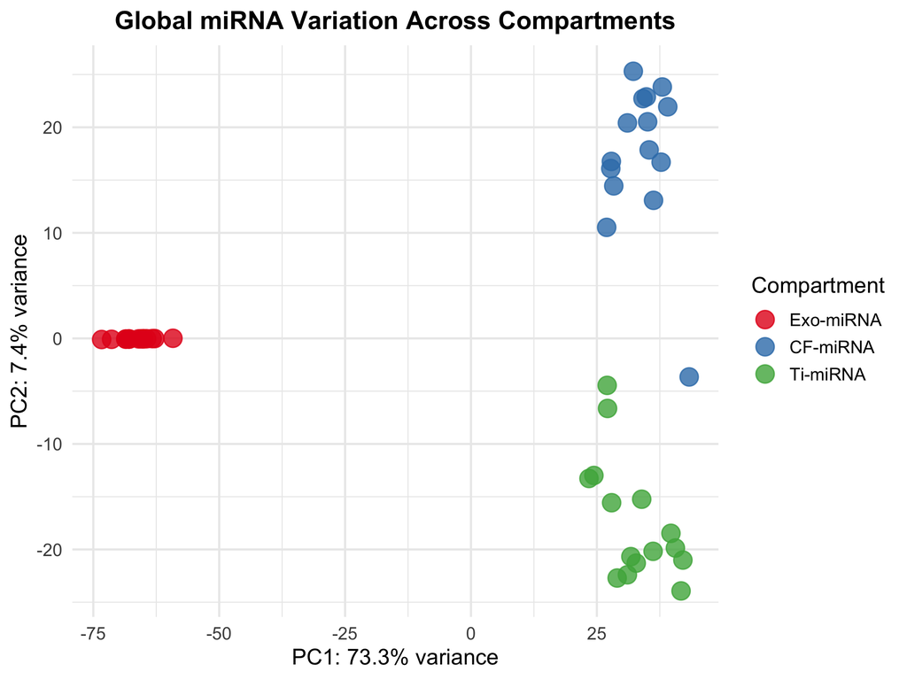

```r
p <- ggplot(pcaData, aes(x = PC1, y = PC2, color = CompartmentLabel)) +
  geom_point(size = 5, alpha = 0.8) +
  theme_minimal(base_size = 14) +
  labs(
    title = "Global miRNA Variation Across Compartments",
    x = paste0("PC1: ", round(percentVar[1], 1), "% variance"),
    y = paste0("PC2: ", round(percentVar[2], 1), "% variance"),
    color = "Compartment"
  ) +
  scale_color_brewer(palette = "Set1") +
  theme(
    plot.title = element_text(hjust = 0.5, size = 16, face = "bold")
  )

print(p)
```

```r
ggsave("PCA_plot.png", plot = p, width = 6, height = 5, dpi = 300)
#### Step 8:  Plotting PCA
```

#### Heatmap of Top 20 Differentially Expressed miRNAs

To visualise expression patterns across compartments, we generated a heatmap using the top 20 most significant miRNAs from each pairwise comparison. Variance-stabilized counts were used to improve comparability across samples. Expression values were scaled by row (miRNA-wise z-score transformation) to highlight relative expression differences between compartments.

##### Step 1: Select Top 20 miRNAs from Each Comparison

```r
top_miRNAs <- unique(c(
  rownames(sig_exo_vs_cf)[1:20],
  rownames(sig_exo_vs_ti)[1:20],
  rownames(sig_ti_vs_cf)[1:20]
))
```

##### Step 2: Extract the variance-stabilized expression counts for the selected miRNAs from the `vsd` object.

```r
mat <- assay(vsd)[top_miRNAs, ]
mat_scaled <- t(scale(t(mat)))
mat_scaled[is.na(mat_scaled)] <- 0
```

##### Step 3: Scale the expression values row-wise (z-score per miRNA) to normalize for differences in expression magnitude.

```r
annotation_col <- data.frame(
  Compartment = colData(dds)$Compartment
)
```

##### Step 4: Prepare sample annotation information based on the compartment (`Exo-miRNA`, `CF-miRNA`, `Ti-miRNA`) for labeling in the heatmap.

```r
rownames(annotation_col) <- colnames(mat_scaled)
annotation_col$Compartment <- factor(
  annotation_col$Compartment,
  levels = c("exo", "cf", "ti"),
  labels = c("Exo-miRNA", "CF-miRNA", "Ti-miRNA")
)
```

##### Step 5: Define colors for each compartment to use in the annotation.

```r
ann_colors <- list(
  Compartment = c(
    "Exo-miRNA" = "#1f77b4",  # blue
    "CF-miRNA"  = "#ff7f0e",  # orange
    "Ti-miRNA"  = "#2ca02c"   # green
  )
)
```

##### Step 6: Generate the heatmap with row and column clustering, displaying miRNA names on rows and compartments as colored annotations.

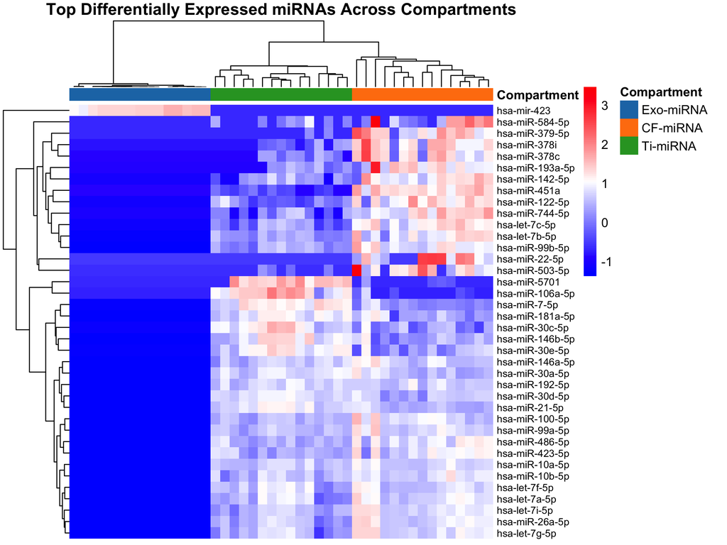

```r
pdf("heatmap_miRNA.p", width = 7, height = 8)
pheatmap(
  mat_scaled,
  cluster_rows = TRUE,
  cluster_cols = TRUE,
  annotation_col = annotation_col,
  annotation_colors = ann_colors,
  show_rownames = TRUE,
  show_colnames = FALSE,
  fontsize_row = 8,
  border_color = NA,
  color = colorRampPalette(c("blue", "white", "red"))(100),
  main = "  Top Differentially Expressed miRNAs Across Compartments  "
)
```

```r
dev.off()
```

Figure 2: Heatmap of top differentially expressed miRNAs across biological compartments. Heatmap showing the expression patterns of the most significant miRNAs identified from pairwise comparisons between tissue, exosome, and cell-free (CF) compartments. The top 20 miRNAs from each comparison were selected and combined into a non-redundant set. Expression values were derived from variance-stabilized counts and scaled per miRNA (row-wise z-score) to emphasize relative differences across samples. Each column represents an individual sample, and each row represents a miRNA. Samples are annotated by compartment (Exo-miRNA, CF-miRNA, Ti-miRNA) and clustered based on expression similarity. Distinct clustering patterns highlight compartment-specific miRNA signatures, with exosomal samples forming a more homogeneous group compared to the more variable tissue and CF samples

#### Volcano Plot Analysis for Each Comparison

We next examine differential miRNA expression using volcano plots for each pairwise comparison. These plots display log2 fold change on the x-axis and statistical significance on the y-axis, allowing clear identification of significantly upregulated and downregulated miRNAs across compartments.

Make sure your DESeq2 object exists then Differential expression results

```r
res_exo_vs_cf <- results(dds, contrast = c("Compartment", "exo", "cf"))
res_exo_vs_ti <- results(dds, contrast = c("Compartment", "exo", "ti"))
res_cf_vs_ti <- results(dds, contrast = c("Compartment", "cf", "ti"))
```

Step 2: Convert results to data frames and add miRNA names

```r
res_exo_vs_cf_df <- as.data.frame(res_exo_vs_cf)
res_exo_vs_cf_df$miRNA <- rownames(res_exo_vs_cf_df)
```

```r
res_exo_vs_ti_df <- as.data.frame(res_exo_vs_ti)
res_exo_vs_ti_df$miRNA <- rownames(res_exo_vs_ti_df)
```

```r
res_cf_vs_ti_df <- as.data.frame(res_cf_vs_ti)
res_cf_vs_ti_df$miRNA <- rownames(res_cf_vs_ti_df)
```

Step 3: Replace NA or zero padj values

```r
# exo vs cf
res_exo_vs_cf_df$padj[is.na(res_exo_vs_cf_df$padj)] <- 1
res_exo_vs_cf_df$padj[res_exo_vs_cf_df$padj == 0] <- 1e-300

# exo vs ti
res_exo_vs_ti_df$padj[is.na(res_exo_vs_ti_df$padj)] <- 1
res_exo_vs_ti_df$padj[res_exo_vs_ti_df$padj == 0] <- 1e-300

# cf vs ti
res_cf_vs_ti_df$padj[is.na(res_cf_vs_ti_df$padj)] <- 1
res_cf_vs_ti_df$padj[res_cf_vs_ti_df$padj == 0] <- 1e-300
```

#### Step 4: Add Significance column (Up / Down / NS)

```r
# exo vs cf
res_exo_vs_cf_df$Significance <- "NS"
res_exo_vs_cf_df$Significance[res_exo_vs_cf_df$padj < 0.05 & res_exo_vs_cf_df$log2FoldChange > 0] <- "Up"
res_exo_vs_cf_df$Significance[res_exo_vs_cf_df$padj < 0.05 & res_exo_vs_cf_df$log2FoldChange < 0] <- "Down"

# exo vs ti
res_exo_vs_ti_df$Significance <- "NS"
res_exo_vs_ti_df$Significance[res_exo_vs_ti_df$padj < 0.05 & res_exo_vs_ti_df$log2FoldChange > 0] <- "Up"
res_exo_vs_ti_df$Significance[res_exo_vs_ti_df$padj < 0.05 & res_exo_vs_ti_df$log2FoldChange < 0] <- "Down"

# cf vs ti
res_cf_vs_ti_df$Significance <- "NS"
res_cf_vs_ti_df$Significance[res_cf_vs_ti_df$padj < 0.05 & res_cf_vs_ti_df$log2FoldChange > 0] <- "Up"
res_cf_vs_ti_df$Significance[res_cf_vs_ti_df$padj < 0.05 & res_cf_vs_ti_df$log2FoldChange < 0] <- "Down"
```

##### Step 5: Define a volcano plot function

```r
plot_volcano <- function(res_df, title, filename = NULL) {

  top_labels <- res_df %>%
    filter(padj < 0.05) %>%
    arrange(desc(abs(log2FoldChange))) %>%
    head(10)

  p <- ggplot(res_df, aes(x = log2FoldChange, y = -log10(padj), color = Significance)) +
    geom_point(alpha = 0.6, size = 2) +
    geom_vline(xintercept = 0, linetype = "dashed") +
    geom_hline(yintercept = -log10(0.05), linetype = "dotted", color = "blue") +
    scale_color_manual(values = c("Up" = "red", "Down" = "blue", "NS" = "grey")) +
    geom_text_repel(
      data = top_labels,
      aes(label = miRNA),
      size = 3.5,
      color = "black",
      max.overlaps = 20,
      box.padding = 0.4
    ) +
    theme_minimal() +
    labs(
      title = title,
      x = "log2 Fold Change",
      y = "-log10(FDR)"
    ) +
    theme(plot.title = element_text(hjust = 0.5, size = 16))

  if (!is.null(filename)) {
    ggsave(filename, plot = p, width = 8, height = 6)
  }

  return(p)
}
#### Step 5: Plot volcano plots for each comparison
```

[figure not shown]

[output not shown]

[figure not shown]

```r
 if(!dir.exists("figures")) dir.create("figures", recursive = TRUE)
plot_volcano(res_exo_vs_cf_df, "Exo vs CF-miRNA Comparison", "figures/volcano_exo_vs_cf.pdf")
```

Y-axis: Represents log10(FDR), the negative log10 of the false discovery rate-adjusted p-value. Points located higher on the y-axis represent miRNAs with more statistically significant differences.

Data points (miRNAs) are color-coded based on their expression status:

Grey (NS): miRNAs showing no significant change between conditions

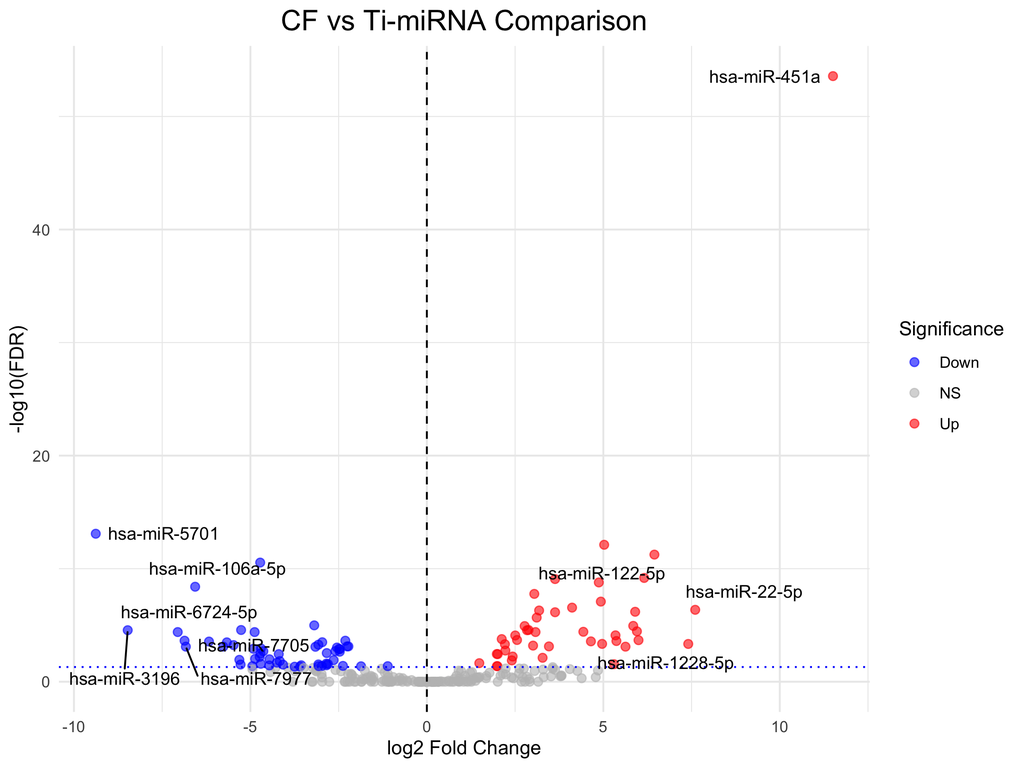

```r
plot_volcano(res_cf_vs_ti_df, "CF vs Ti-miRNA Comparison", "figures/volcano_cf_vs_ti.pdf")
```

Figure 5: This volcano plot comparing CF vs Ti-miRNA expression. It illustrates the relationship between statistical significance and expression changes for miRNAs across these two conditions.

X-axis: Represents the log2 Fold Change, indicating the magnitude and direction of expression differences. Positive values denote upregulation in CF compared to Ti-miRNA, while negative values denote downregulation.

Y-axis: Represents log10(FDR), the negative log10 of the false discovery rate-adjusted p-value. Points positioned higher on the y-axis correspond to miRNAs with greater statistical significance.

Data points (miRNAs) are color-coded based on their expression status:

Red (Up): miRNAs significantly upregulated in CF vs Ti-miRNA

Blue (Down): miRNAs significantly downregulated in CF vs Ti-miRNA

Grey (NS): miRNAs showing no significant change between conditions

This visualization effectively highlights differentially expressed miRNAs that are both statistically significant and show meaningful fold changes between CF and Ti-miRNA samples.

#### Combine volcano plot for three compartments

This combined plot will allow us to compare differential miRNA expression across all compartments in a single view. Significant miRNAs will be highlighted, and the top upregulated and downregulated miRNAs from each comparison will be labeled.

##### Step 1: Add comparison labels to each result

Each differential expression result (from DESeq2) is tagged with a Comparison column so we can combine them later.

```r
res_exo_vs_cf_df$Comparison <- "Exo vs CF"
res_exo_vs_ti_df$Comparison <- "Exo vs Ti"
res_cf_vs_ti_df$Comparison <- "CF vs Ti"
```

#### Step 2: Combine all comparisons into a single data frame

After adding the comparison labels, we merge all three data frames. We also remove any rows with missing padj values and set the order of comparisons for plotting.

```r
combined_volcano <- rbind(
  res_exo_vs_cf_df,
  res_exo_vs_ti_df,
  res_cf_vs_ti_df
)

combined_volcano <- combined_volcano[!is.na(combined_volcano$padj), ]

combined_volcano$Comparison <- factor(
  combined_volcano$Comparison,
  levels = c("Exo vs Ti", "CF vs Ti", "Exo vs CF")
)
```

#### Step 3: Define significance and select top miRNAs

We categorize each miRNA as Significant or Not Significant based on FDR (padj < 0.05) and log2 fold change. The top 10 upregulated and top 10 downregulated miRNAs from each comparison are selected for labeling.

```r
combined_volcano <- combined_volcano %>%
  mutate(
    significance = ifelse(padj < 0.05 & abs(log2FoldChange) > 1,
                          "Significant",
                          "Not Significant"),
    direction = ifelse(log2FoldChange > 0, "Up", "Down")
  )

top_hits <- combined_volcano %>%
  filter(padj < 0.05) %>%
  group_by(Comparison, direction) %>%
  arrange(padj) %>%
  slice_head(n = 10) %>%
  ungroup()
```

#### Step 5: Combined volcano plot

We use ggplot2 and ggrepel to:

Plot all miRNAs

Highlight significant miRNAs in red

Highlight top hits in blue

Label top miRNAs

Facet by comparison

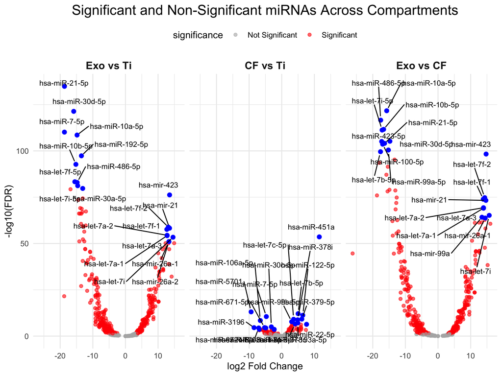

```r
 p <- ggplot(combined_volcano,
            aes(x = log2FoldChange, y = -log10(padj))) +
  geom_point(aes(color = significance), alpha = 0.6) +
  geom_point(data = top_hits, color = "blue", size = 2) +
  geom_text_repel(
    data = top_hits,
    aes(label = miRNA),
    size = 3,
    max.overlaps = 50,
    box.padding = 0.5,
    point.padding = 0.3
  ) +
  facet_wrap(~ Comparison, nrow = 1) +
  scale_color_manual(values = c(
    "Not Significant" = "grey70",
    "Significant" = "red"
  )) +
  theme_minimal() +
  labs(
    title = "Significant and Non-Significant miRNAs Across Compartments",
    x = "log2 Fold Change",
    y = "-log10(FDR)"
  ) +
  theme(
    plot.title = element_text(hjust = 0.5, size = 16),
    legend.position = "top",
    strip.text = element_text(face = "bold", size = 12)
  )

p
```

##### Step 1:

in first step we create a miRNA type annotation and extract normalized counts by following codes:

#####1a. Check the miRNA names in the DESeq2 object

```r
head(rownames(dds), 20)
```

```
##  [1] "hsa-let-7a-1"   "hsa-let-7a-2"   "hsa-let-7a-3"   "hsa-let-7a-5p"
##  [5] "hsa-let-7b"     "hsa-let-7b-5p"  "hsa-let-7c"     "hsa-let-7c-5p"
##  [9] "hsa-let-7d"     "hsa-let-7d-5p"  "hsa-let-7e"     "hsa-let-7e-5p"
## [13] "hsa-let-7f-1"   "hsa-let-7f-2"   "hsa-let-7f-5p"  "hsa-let-7g"
## [17] "hsa-let-7g-5p"  "hsa-let-7i"     "hsa-let-7i-5p"  "hsa-miR-100-5p"
```

1b. Create a data frame with miRNA names

```r
miRNA_df <- data.frame(miRNA = rownames(dds))
```

1c. Assign type based on name convention: Mature vs Precursor

```r
miRNA_df$Type <- ifelse(
  grepl("-[35]p$", miRNA_df$miRNA),
  "Mature",
  "Precursor"
)
```

1d. Inspect first few entries

```r
head(miRNA_df, 10)
```

| miRNA | Type |
| --- | --- |
| hsa-let-7a-1 | Precursor |
| hsa-let-7a-2 | Precursor |
| hsa-let-7a-3 | Precursor |
| hsa-let-7a-5p | Mature |
| hsa-let-7b | Precursor |
| hsa-let-7b-5p | Mature |
| hsa-let-7c | Precursor |
| hsa-let-7c-5p | Mature |
| hsa-let-7d | Precursor |
| hsa-let-7d-5p | Mature |

1e. Extract normalized counts from DESeq2

```r
norm_counts <- counts(dds, normalized = TRUE)
```

1f.Convert to data frame

```r
norm_df <- as.data.frame(norm_counts)
```

1g. Add miRNA names as a column for easier merging

```r
norm_df$miRNA <- rownames(norm_df)
```

lets check

```r
head(norm_df, 10)
```

|  | SRR25680444_exo | SRR25680445_exo | SRR25680447_exo | SRR25680448_exo | SRR25680449_exo | SRR25680450_exo | SRR25680451_exo | SRR25680452_exo | SRR25680454_exo | SRR25680455_exo | SRR25680456_exo | SRR25680457_exo | SRR25680458_exo | SRR25680459_exo | SRR25680460_exo | SRR25680461_cf | SRR25680462_cf | SRR25680465_cf | SRR25680466_cf | SRR25680467_cf | SRR25680468_cf | SRR25680469_cf | SRR25680470_cf | SRR25680471_cf | SRR25680472_cf | SRR25680473_cf | SRR25680474_cf | SRR25680476_cf | SRR25680477_cf | … |
| --- | --- | --- | --- | --- | --- | --- | --- | --- | --- | --- | --- | --- | --- | --- | --- | --- | --- | --- | --- | --- | --- | --- | --- | --- | --- | --- | --- | --- | --- | --- |
| hsa-let-7a-1 | 3152.99521 | 3596.38693 | 2769.60977 | 2748.11729 | 1098.80254 | 296.397910 | 3974.49305 | 2888.8733 | 198.535372 | 374.07425 | 2637.91211 | 3722.67653 | 7218.4798 | 3257.85555 | 944.03769 | 0.0000 | 0.0000 | 0.00000 | 0.00000 | 0.0000 | 0.00000 | 0.0000 | 0.0000 | 0.00000 | 0.00000 | 0.00000 | 0.00000 | 0.0000 | 0.00000 | … |
| hsa-let-7a-2 | 3134.04566 | 3596.38693 | 2766.65675 | 2745.33860 | 1098.80254 | 296.397910 | 3959.50627 | 2882.8907 | 209.606118 | 375.14918 | 2632.20763 | 3724.39965 | 7197.1432 | 3273.44338 | 940.90223 | 0.0000 | 0.0000 | 0.00000 | 0.00000 | 0.0000 | 0.00000 | 0.0000 | 0.0000 | 0.00000 | 0.00000 | 0.00000 | 0.00000 | 0.0000 | 0.00000 | … |
| hsa-let-7a-3 | 3143.52044 | 3597.49181 | 2781.42188 | 2753.21154 | 1098.80254 | 303.392551 | 3965.50098 | 2882.4305 | 198.535372 | 374.07425 | 2641.57927 | 3726.36892 | 7203.8657 | 3255.90707 | 940.37965 | 0.0000 | 0.0000 | 0.00000 | 0.00000 | 0.0000 | 0.00000 | 0.0000 | 0.0000 | 0.00000 | 0.00000 | 0.00000 | 0.00000 | 0.0000 | 0.00000 | … |
| hsa-let-7a-5p | 0.00000 | 0.00000 | 0.00000 | 0.00000 | 0.00000 | 0.000000 | 0.00000 | 0.0000 | 0.000000 | 0.00000 | 0.00000 | 0.00000 | 0.0000 | 0.00000 | 0.00000 | 8135.4360 | 6070.9152 | 27105.22879 | 2306.69390 | 3096.1734 | 1832.68936 | 4699.3141 | 7354.2091 | 774.04191 | 750.27687 | 1408.66897 | 1645.16718 | 6214.3221 | 1841.52066 | … |
| hsa-let-7b | 5356.40723 | 5742.06540 | 5753.14984 | 10947.08400 | 1938.05767 | 257.053054 | 3162.20978 | 1243.8345 | 148.347992 | 177.36279 | 3633.75041 | 7987.39720 | 1060.9824 | 1687.38212 | 11591.57051 | 0.0000 | 0.0000 | 0.00000 | 0.00000 | 0.0000 | 0.00000 | 0.0000 | 0.0000 | 0.00000 | 0.00000 | 0.00000 | 0.00000 | 0.0000 | 0.00000 | … |
| hsa-let-7b-5p | 0.00000 | 0.00000 | 0.00000 | 0.00000 | 0.00000 | 0.000000 | 0.00000 | 0.0000 | 0.000000 | 0.00000 | 0.00000 | 0.00000 | 0.0000 | 0.00000 | 0.00000 | 49728.5905 | 32706.4593 | 129969.08631 | 39674.99552 | 26268.5662 | 1995.40206 | 717.3232 | 6318.9495 | 130.36495 | 1803.04632 | 19255.97379 | 8101.63734 | 11559.0334 | 6047.98176 | … |
| hsa-let-7c | 441.10350 | 471.78409 | 93.84059 | 376.51152 | 163.18850 | 75.192390 | 265.26594 | 133.8268 | 114.397705 | 77.39467 | 389.94160 | 580.93742 | 850.8319 | 350.72608 | 3267.42081 | 0.0000 | 0.0000 | 0.00000 | 0.00000 | 0.0000 | 0.00000 | 0.0000 | 0.0000 | 0.00000 | 0.00000 | 0.00000 | 0.00000 | 0.0000 | 0.00000 | … |
| hsa-let-7c-5p | 0.00000 | 0.00000 | 0.00000 | 0.00000 | 0.00000 | 0.000000 | 0.00000 | 0.0000 | 0.000000 | 0.00000 | 0.00000 | 0.00000 | 0.0000 | 0.00000 | 0.00000 | 1776.3538 | 733.7025 | 366.39941 | 423.54089 | 519.2365 | 517.09055 | 530.9321 | 1348.8444 | 69.25638 | 85.74593 | 271.73880 | 419.86520 | 946.2768 | 469.93162 | … |
| hsa-let-7d | 44.21563 | 37.56595 | 113.85554 | 54.64743 | 15.54176 | 9.617631 | 62.94446 | 327.5719 | 8.118547 | 23.64837 | 36.67162 | 31.01615 | 102.5909 | 50.66043 | 58.26748 | 0.0000 | 0.0000 | 0.00000 | 0.00000 | 0.0000 | 0.00000 | 0.0000 | 0.0000 | 0.00000 | 0.00000 | 0.00000 | 0.00000 | 0.0000 | 0.00000 | … |
| hsa-let-7d-5p | 0.00000 | 0.00000 | 0.00000 | 0.00000 | 0.00000 | 0.000000 | 0.00000 | 0.0000 | 0.000000 | 0.00000 | 0.00000 | 0.00000 | 0.0000 | 0.00000 | 0.00000 | 171.4447 | 139.0453 | 86.04835 | 44.86465 | 130.9500 | 34.16388 | 256.2506 | 25.7741 | 12.22171 | 16.67282 | 53.09839 | 40.78161 | 100.7610 | 15.28233 | … |

1h. Create miRNA type table (simplified)

```r
miRNA_type <- data.frame(
  miRNA = rownames(norm_counts),
  Type = miRNA_df$Type
)
```

Check total miRNAs

```r
nrow(norm_counts)
```

```
## [1] 507
```

```r
head(miRNA_type)
```

| miRNA | Type |
| --- | --- |
| hsa-let-7a-1 | Precursor |
| hsa-let-7a-2 | Precursor |
| hsa-let-7a-3 | Precursor |
| hsa-let-7a-5p | Mature |
| hsa-let-7b | Precursor |
| hsa-let-7b-5p | Mature |

#### Step 2: Define sample groups

Identify samples belonging to each compartment

```r
exo_samples <- colnames(norm_counts)[grep("_exo", colnames(norm_counts))]
ti_samples  <- colnames(norm_counts)[grep("_ti", colnames(norm_counts))]
cf_samples  <- colnames(norm_counts)[grep("_cf", colnames(norm_counts))]
```

Inspect

```r
head(exo_samples)
```

```
## [1] "SRR25680444_exo" "SRR25680445_exo" "SRR25680447_exo" "SRR25680448_exo"
## [5] "SRR25680449_exo" "SRR25680450_exo"
```

```r
head(ti_samples)
```

```
## [1] "SRR25680400_ti" "SRR25680409_ti" "SRR25680420_ti" "SRR25680431_ti"
## [5] "SRR25680442_ti" "SRR25680453_ti"
```

```r
head(cf_samples)
```

```
## [1] "SRR25680461_cf" "SRR25680462_cf" "SRR25680465_cf" "SRR25680466_cf"
## [5] "SRR25680467_cf" "SRR25680468_cf"
```

#### Step 3: Prepare barplot data

```r
# Function to calculate total counts per miRNA per compartment for any two groups
prepare_bar_data <- function(norm_counts, miRNA_type, group1, group2, name1, name2) {

  # Subset counts for selected groups
  counts_subset <- norm_counts[, c(group1, group2)]

  # Sum counts per miRNA
  total_counts <- data.frame(
    miRNA = rownames(counts_subset),
    Comp1 = rowSums(counts_subset[, group1, drop = FALSE]),
    Comp2 = rowSums(counts_subset[, group2, drop = FALSE])
  )

  # Rename columns to meaningful compartment names
  colnames(total_counts) <- c("miRNA", name1, name2)

  # Merge with miRNA type
  total_counts <- merge(total_counts, miRNA_type, by = "miRNA")

 # Pivot longer for ggplot
  counts_long <- total_counts %>%
    pivot_longer(
      cols = c(name1, name2),
      names_to = "Compartment",
      values_to = "TotalCounts"
    )

  return(counts_long)
}
```

#### Step 4: Create data for each pairwise comparison

```r
# Exo vs Ti
data_exo_ti <- prepare_bar_data(norm_counts, miRNA_type, exo_samples, ti_samples, "Exo", "Ti")

# Exo vs CF
data_exo_cf <- prepare_bar_data(norm_counts, miRNA_type, exo_samples, cf_samples, "Exo", "CF")

# Ti vs CF
data_ti_cf  <- prepare_bar_data(norm_counts, miRNA_type, ti_samples, cf_samples, "Ti", "CF")
```

Inspect first few rows

```r
head(data_exo_ti)
```

| miRNA | Type | Compartment | TotalCounts |
| --- | --- | --- | --- |
| hsa-let-7a-1 | Precursor | Exo | 38879.25 |
| hsa-let-7a-1 | Precursor | Ti | 0.00 |
| hsa-let-7a-2 | Precursor | Exo | 38832.88 |
| hsa-let-7a-2 | Precursor | Ti | 0.00 |
| hsa-let-7a-3 | Precursor | Exo | 38866.48 |
| hsa-let-7a-3 | Precursor | Ti | 0.00 |

#### Step 5: Combine comparisons and log-transform counts

Add a Comparison column to each dataset

```r
data_exo_ti  <- data_exo_ti  %>% mutate(Comparison = "Exo_vs_Ti")
data_exo_cf  <- data_exo_cf  %>% mutate(Comparison = "Exo_vs_CF")
data_ti_cf   <- data_ti_cf   %>% mutate(Comparison = "Ti_vs_CF")
```

Combine all three comparisons

```r
counts_all <- bind_rows(data_exo_ti, data_exo_cf, data_ti_cf)
```

#### Add log2-transformed counts (log2(TotalCounts + 1) to avoid log(0))

```r
counts_all <- counts_all %>%
  mutate(logCounts = log2(TotalCounts + 1))
```

Inspect

```r
  head(counts_all)
```

| miRNA | Type | Compartment | TotalCounts | Comparison | logCounts |
| --- | --- | --- | --- | --- | --- |
| hsa-let-7a-1 | Precursor | Exo | 38879.25 | Exo_vs_Ti | 15.24675 |
| hsa-let-7a-1 | Precursor | Ti | 0.00 | Exo_vs_Ti | 0.00000 |
| hsa-let-7a-2 | Precursor | Exo | 38832.88 | Exo_vs_Ti | 15.24503 |
| hsa-let-7a-2 | Precursor | Ti | 0.00 | Exo_vs_Ti | 0.00000 |
| hsa-let-7a-3 | Precursor | Exo | 38866.48 | Exo_vs_Ti | 15.24628 |
| hsa-let-7a-3 | Precursor | Ti | 0.00 | Exo_vs_Ti | 0.00000 |

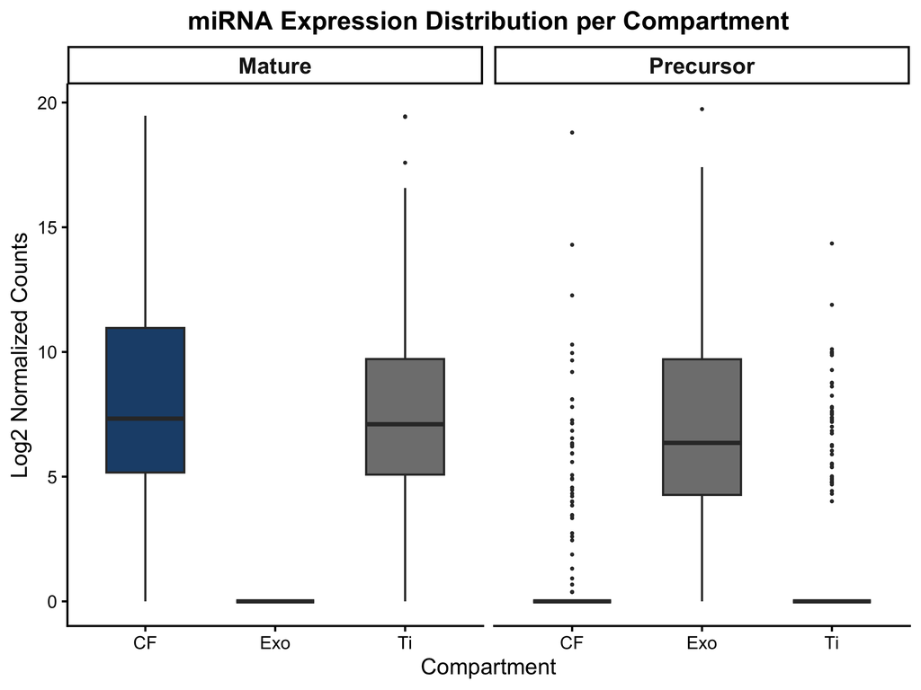

```r
 p <- ggplot(counts_all,
            aes(x = Compartment,
                y = logCounts,
                fill = Compartment)) +

  geom_boxplot(width = 0.6, outlier.size = 0.5) +

  facet_wrap(~Type) +

  scale_fill_manual(values = c(
    "EXO" = "#b22222",
    "TI"  = "#2e8b57",
    "CF"  = "#1f4e79"
  )) +

  labs(
    title = "miRNA Expression Distribution per Compartment",
    x = "Compartment",
    y = "Log2 Normalized Counts"
  ) +

  theme_classic(base_size = 14) +

  theme(
    strip.text = element_text(size = 14, face = "bold"),
    plot.title = element_text(size = 16, face = "bold", hjust = 0.5),
    legend.position = "none"
  )


print(p)
```

#### miRNA Overlap Across Compartments:

To understand how miRNAs are shared between Exosome (Exo), Tissue (Ti), and Cell-free (CF) compartments, we performed an overlap analysis. Using the normalized counts, miRNAs detected in each compartment were extracted, and a Venn diagram was generated to visualize shared and unique miRNAs. This analysis helps to identify compartment-specific miRNAs as well as those potentially leaking from tissue into circulation or packaged in exosomes.

Exo-specific miRNAs represent miRNAs preferentially packaged into exosomes.

Ti-specific miRNAs indicate miRNAs expressed primarily in tissue.

CF-specific miRNAs may reflect a combination of tissue leakage and extracellular release.

Shared miRNAs suggest common expression or inter-compartmental transfer, supporting biological relationships between compartments.

##### Step 1: Identify Samples for Each Compartment

Before analyzing overlaps, we first define the sample groups based on compartment. The normalized counts (norm_counts) have column names ending with _exo, _ti, and _cf, which correspond to Exosome, Tissue, and Cell-free compartments, respectively. We extract the sample names for each compartment to facilitate downstream analyses.

##### 1a: Extract sample names for each compartment

```r
exo_samples <- colnames(norm_counts)[grep("_exo", colnames(norm_counts))]
ti_samples  <- colnames(norm_counts)[grep("_ti", colnames(norm_counts))]
cf_samples  <- colnames(norm_counts)[grep("_cf", colnames(norm_counts))]
```

##### 1b: Check the first few sample names

```r
  head(exo_samples)
```

```
## [1] "SRR25680444_exo" "SRR25680445_exo" "SRR25680447_exo" "SRR25680448_exo"
## [5] "SRR25680449_exo" "SRR25680450_exo"
```

```r
  head(ti_samples)
```

```
## [1] "SRR25680400_ti" "SRR25680409_ti" "SRR25680420_ti" "SRR25680431_ti"
## [5] "SRR25680442_ti" "SRR25680453_ti"
```

```r
  head(cf_samples)
```

```
## [1] "SRR25680461_cf" "SRR25680462_cf" "SRR25680465_cf" "SRR25680466_cf"
## [5] "SRR25680467_cf" "SRR25680468_cf"
```

#### Step 2: Get Detected miRNAs per Compartment

To identify which miRNAs are present in each compartment, we define a miRNA as “detected” if it has a normalized count greater than zero in at least one sample of that compartment. This allows us to generate lists of miRNAs for Exosome, Tissue, and Cell-free compartments for overlap analysis.

##### Step 2a: Detected miRNAs

```r
exo_miRNAs <- rownames(norm_counts)[rowSums(norm_counts[, exo_samples, drop=FALSE]) > 0]
  ti_miRNAs  <- rownames(norm_counts)[rowSums(norm_counts[, ti_samples, drop=FALSE]) > 0]
  cf_miRNAs  <- rownames(norm_counts)[rowSums(norm_counts[, cf_samples, drop=FALSE]) > 0]
```

#### Step 3: Check numbers of detected miRNAs per compartment

```r
length(exo_miRNAs)
```

```
## [1] 243
```

```r
  length(ti_miRNAs)
```

```
## [1] 250
```

```r
  length(cf_miRNAs)
```

```
## [1] 260
```

#### Step 4: Prepare miRNA Lists for Overlap Analysis

###### use rownames of normalized counts with >5 expression

```r
exo_miRNAs <- rownames(norm_counts)[rowSums(norm_counts[, exo_samples] > 5) >= 2]
ti_miRNAs  <- rownames(norm_counts)[rowSums(norm_counts[, ti_samples] > 5) >= 2]
cf_miRNAs  <- rownames(norm_counts)[rowSums(norm_counts[, cf_samples] > 5) >= 2]
```

####Step 5: Create the Venn Diagram Using the prepared miRNA lists, we can visualize overlaps between compartments. Each circle represents a compartment, and the intersections indicate miRNAs shared between them. This supports understanding of compartment-specific miRNAs and those commonly expressed.

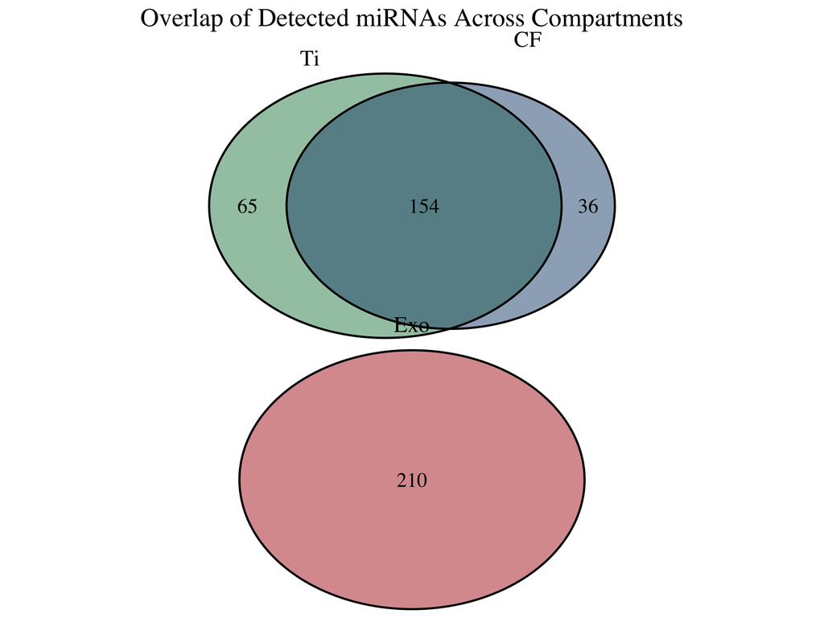

```r
venn.plot <- venn.diagram(
    x = list(
      Exo = exo_miRNAs,
      Ti  = ti_miRNAs,
      CF  = cf_miRNAs
    ),
    filename = NULL,
    fill = c("#b22222", "#2e8b57", "#1f4e79"),
    alpha = 0.5,
    cex = 1.2,
    cat.cex = 1.3,
    cat.pos = c(-20, 20, 0),   # keep simple
    cat.dist = c(0.05, 0.05, 0.07),  # small push for CF
    lwd = 2,
    main = "Overlap of Detected miRNAs Across Compartments",
    main.cex = 1.5
  )
   grid.draw(venn.plot)
```

```r
# Create figures directory (check carefully: 'if' not 'f')
if(!dir.exists("figures")) dir.create("figures")

 # Create plot object
venn.plot <- venn.diagram(
  x = list(
    Exo = exo_miRNAs,
    Ti  = ti_miRNAs,
    CF  = cf_miRNAs
  ),
  filename = NULL,
  fill = c("#b22222", "#2e8b57", "#1f4e79"),
  alpha = 0.5,
  cex = 1.2,
  cat.cex = 1.3,
  lwd = 2
)

# Save manually
pdf("figures/venn_miRNA.pdf", width = 6, height = 6)
grid.draw(venn.plot)
```